# Prediction Of Manner Of The Exercise

Swapnil Jamthe

19 June 2015

## Summary

Data from accelerometers on the belt, forearm, arm, and dumbell of 6 participants was collected. They were asked to perform barbell lifts correctly and incorrectly in 5 different ways. Models are built to predict the manner in which they did the exercise. More information is available at http://groupware.les.inf.puc-rio.br/har.

## Shortlisting features

Removed following columns from the data.  
1. Columns with more than 50% of values having “NA”.  
2. Columns with more than 50% of empty values.  
3. user_name, new_window, num_window columns.

## Dividing data

Data is divided into following.  
1. 20% of data is used for calculation of out of sample error.  
2. Out of remaining data 20% is used as cross validation of different models.  
3. Remaining data is used as training set.

## Prediction Models

Following prediction models are tried which are trained on training set.  
1. rpart5 - Classification tree with 5 fold cross validation  
2. rpart10 - Classification tree with 10 fold cross validation  
3. rf5 - Random forest with 5 fold cross validation  
4. gbm5 - Boosted trees with 5 fold cross validation  
5. gbm10 - Boosted tress with 10 fold cross validation

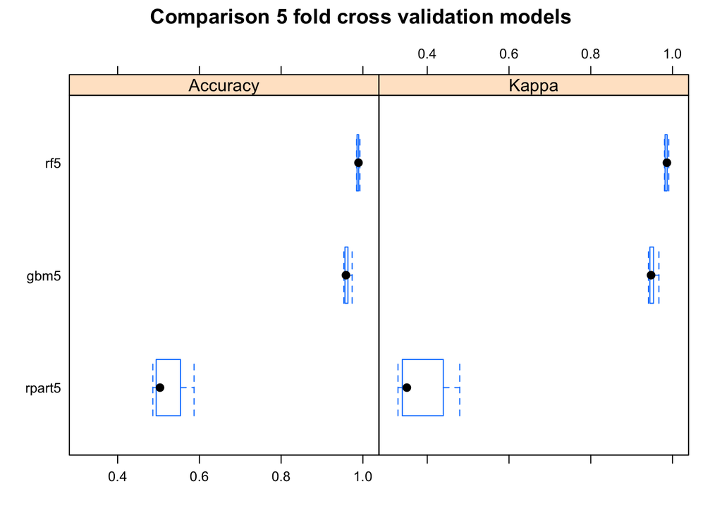

Box plot shows random forest model has better performance than other two.

Following are the accuracies of the models on cross validation set for models.  
1. rpart5 - 0.4708218  
2. rpart10 - 0.4708218  
3. rf5 - 1  
4. gbm5 - 0.977372  
5. gbm10 - 0.977769